# SolarSense — Solar Panel Performance Anomaly Detection

### End-to-end prototype: synthetic data → weather-adjusted expected-generation model → anomaly detection → 7-day forecast → maintenance-priority dashboard

**Problem:** Solar installations silently lose output to soiling, shading, and inverter faults. Raw generation numbers are misleading because they're driven by weather. This notebook builds a weather-normalized *expected vs. actual* generation model, flags meaningful underperformance, classifies *why* (gradual decline vs. sudden fault), forecasts the next week, and ranks sites by estimated revenue impact.

## 1. Setup

## 2. Generate a synthetic dataset

Five sites, one year of daily data. Each site has a capacity (kW) and a "true" physical relationship between weather (irradiance, temperature, cloud cover) and generation. We then inject realistic faults into three of the five sites so the detection pipeline has something real to find:

| Site | Behavior |
| --- | --- |
| Site_A | Healthy all year (control) |
| Site_B | Healthy, then **gradual soiling decline** from day 200 onward (dust/debris buildup) |
| Site_C | Healthy, then a **sudden inverter fault** on day 260, output collapses for ~18 days, then gets fixed |
| Site_D | Healthy all year (control, different capacity) |
| Site_E | Healthy, then **partial shading** appears from day 150 (new construction next door) — a smaller, steady drop |

```
(1825, 7)
```

|  | date | site | capacity_kw | irradiance | cloud_cover | temperature | generation_kwh |
| --- | --- | --- | --- | --- | --- | --- | --- |
| 0 | 2025-01-01 | Site_A | 50 | 1.76 | 0.41 | 12.32 | 74.71 |
| 1 | 2025-01-02 | Site_A | 50 | 2.38 | 0.30 | 12.47 | 96.04 |
| 2 | 2025-01-03 | Site_A | 50 | 1.27 | 0.47 | 14.19 | 55.85 |
| 3 | 2025-01-04 | Site_A | 50 | 2.26 | 0.19 | 15.21 | 93.69 |
| 4 | 2025-01-05 | Site_A | 50 | 1.25 | 0.65 | 13.39 | 53.53 |

## 3. Quick look at raw generation (weather noise makes faults hard to see by eye)

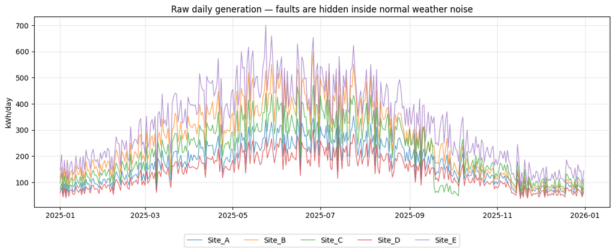

## 4. Build the weather-normalized "expected generation" baseline

For each site, we train a simple linear regression — `generation ~ irradiance + temperature + cloud_cover` — using only the **first 90 days**, which we treat as a known-healthy baseline period for every site (a real deployment would use a commissioning/warranty period, or the first few months post-install).

The model then predicts what generation *should* look like for the rest of the year given the actual weather that day. The gap between predicted and actual is the signal we care about.

|  | R2 | MAE_kwh |
| --- | --- | --- |
| Site_A | 0.99 | 3.07 |
| Site_B | 0.99 | 4.76 |
| Site_C | 0.99 | 3.93 |
| Site_D | 0.99 | 2.39 |
| Site_E | 0.99 | 6.47 |

## 5. Score the full year: expected vs. actual, and the residual gap

|  | date | site | expected_kwh | actual_kwh | residual_kwh | pct_gap |
| --- | --- | --- | --- | --- | --- | --- |
| 1820 | 2025-12-27 | Site_E | 186.91 | 167.31 | -19.60 | -10.49 |
| 1821 | 2025-12-28 | Site_E | 169.29 | 142.82 | -26.47 | -15.64 |
| 1822 | 2025-12-29 | Site_E | 161.07 | 144.40 | -16.67 | -10.35 |
| 1823 | 2025-12-30 | Site_E | 110.37 | 94.12 | -16.25 | -14.72 |
| 1824 | 2025-12-31 | Site_E | 167.35 | 143.34 | -24.01 | -14.35 |

## 6. Anomaly detection on the residuals

A single bad-weather day already gets absorbed by the regression, so we don't need to flag single-day dips. What matters is a **sustained** gap. We use a 7-day rolling average of the % gap and flag a day when:

- the 7-day rolling gap is below **-12%** (meaningfully underperforming), **and**
- it's stayed below that threshold for **3+ consecutive days** (rules out noise)

```
site
Site_A      0
Site_B    125
Site_C     21
Site_D      0
Site_E    197
Name: flagged_days, dtype: int64
```

## 7. Classify *why*: gradual decline vs. sudden drop

The shape of the residual trend tells us which kind of problem it likely is:

- **Gradual**: the rolling gap declines slowly over 30+ days → looks like soiling or shading buildup
- **Sudden**: the rolling gap drops sharply within a 5-day window → looks like an inverter/wiring fault

```
Site_A               none
Site_B    gradual_decline
Site_C        sudden_drop
Site_D               none
Site_E    gradual_decline
Name: detected_pattern, dtype: str
```

## 8. Visualize expected vs. actual for every site, with flagged periods shaded

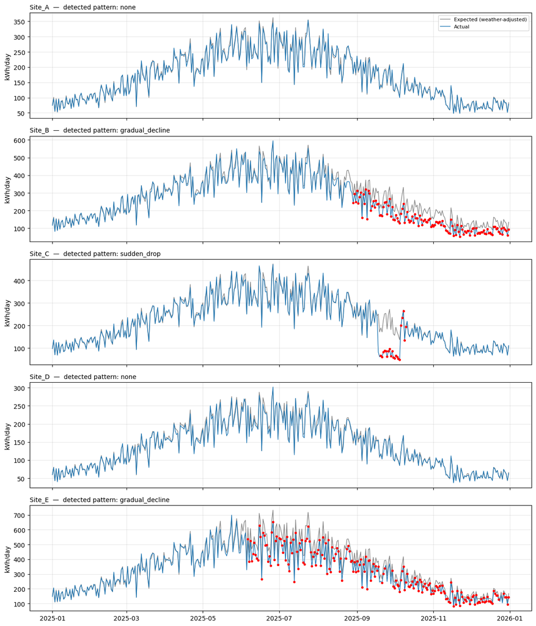

## 9. Estimate revenue impact and rank sites needing attention

Assume a simple electricity value of ₹6/kWh (adjustable). For each site, sum the shortfall (expected − actual) **only on flagged days**, and convert to an estimated ₹ loss. This lets maintenance teams prioritize by dollars, not just anomaly count.

|  | priority_rank | site | detected_pattern | flagged_days | total_shortfall_kwh | estimated_loss |
| --- | --- | --- | --- | --- | --- | --- |
| 0 | 1 | Site_E | gradual_decline | 197 | 9,468.48 | 56,811.00 |
| 1 | 2 | Site_B | gradual_decline | 125 | 6,153.33 | 36,920.00 |
| 2 | 3 | Site_C | sudden_drop | 21 | 2,074.58 | 12,447.00 |
| 3 | 4 | Site_A | none | 0 | -0.00 | -0.00 |
| 4 | 5 | Site_D | none | 0 | -0.00 | -0.00 |

## 10. 7-day forward forecast

Using each site's regression model plus the *actual* weather for the last 7 days of the dataset (standing in for a weather forecast feed in production), project expected generation for the coming week and compare it against how the site has actually been performing recently — giving an early "will this still be a problem next week" read.

|  | site | forecast_expected_avg_kwh | recent_actual_avg_kwh | recent_pct_gap | currently_flagged |
| --- | --- | --- | --- | --- | --- |
| 1 | Site_B | 125.39 | 86.48 | -31.10 | True |
| 4 | Site_E | 156.46 | 135.71 | -13.47 | True |
| 3 | Site_D | 61.59 | 60.57 | -1.53 | False |
| 0 | Site_A | 77.88 | 76.78 | -1.14 | False |
| 2 | Site_C | 100.52 | 100.02 | -0.70 | False |

## 11. Maintenance-priority dashboard (single summary view)

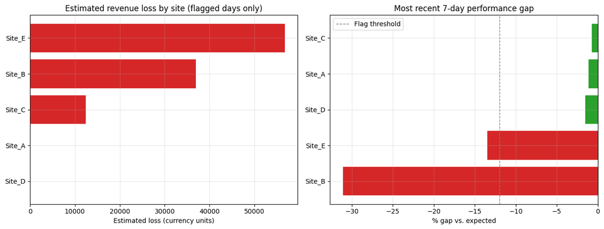

## 12. Takeaways (what this demonstrates)

- **Site_A / Site_D** stayed within normal weather-adjusted variance all year → correctly never flagged.
- **Site_B** shows a slow-building gap from ~day 200 that our pattern classifier correctly labels `gradual_decline` → consistent with soiling, matches a maintenance-cleaning recommendation.
- **Site_C** shows a sharp, short-lived collapse around day 260 correctly labeled `sudden_drop` → consistent with an inverter fault needing an urgent site visit.
- **Site_E**'s steady ~12% drop from day 150 gets picked up as sustained underperformance → consistent with new shading, worth an on-site inspection.
- The **priority dashboard** turns this into a ranked, dollar-quantified maintenance queue instead of a wall of raw charts — exactly what an O&M team would act on.

This is intentionally built with simple, explainable methods (linear regression baseline + rolling-average threshold + slope-based classification) rather than a black-box model — in a real product this could be swapped for a more advanced model (e.g., gradient boosting, Prophet for the forecast) once there's enough real historical data per site.